# Check convergence of MCMCtree runs

See /Users/lukas/sciebo/inquilineGenomics18/phylogeny/TreeDating/MCMCtree/scripts/0baseml.sh for reference and https://github.com/mariodosreis/divtime

**1. Trace plots.** These document the magnitude of the sample drawn (y-axis) at each iteration (x-axis) of the MCMC procedure. Once the chain has identified the stationary distribution of samples, the samples that are drawn will appear to have been randomly sampled from the same region of the y-axis.  
**2. Autocorrelation plots.** These document the correlation (y-axis) of samples at each step of the chain with previous estimates of that same variable, lagged by some number of iterations (x-axis). **Ideally, the autocorrelation declines rapidly, so that it is eventually possible to be confident that the samples from the stationary distribution can be thought of as random, and not reliant on initial values in the chain.** If the autocorrelation fails to diminish, a pattern in the sample draws in the trace plot will become more discernible, suggesting that at the very least, the posterior distribution has not been well characterized by the drawn samples.

Each data frame contains 14 columns: MCMC generation number, 10 node ages (divergence times), 1 mean mutation rates, 1 rate drift coefficients, and sample log-likelihood values

```r
names(mcmc1)
```

```
##  [1] "Gen"    "t_n12"  "t_n13"  "t_n14"  "t_n15"  "t_n16"  "t_n17"
##  [8] "t_n18"  "t_n19"  "t_n20"  "t_n21"  "mu"     "sigma2" "lnL"
```

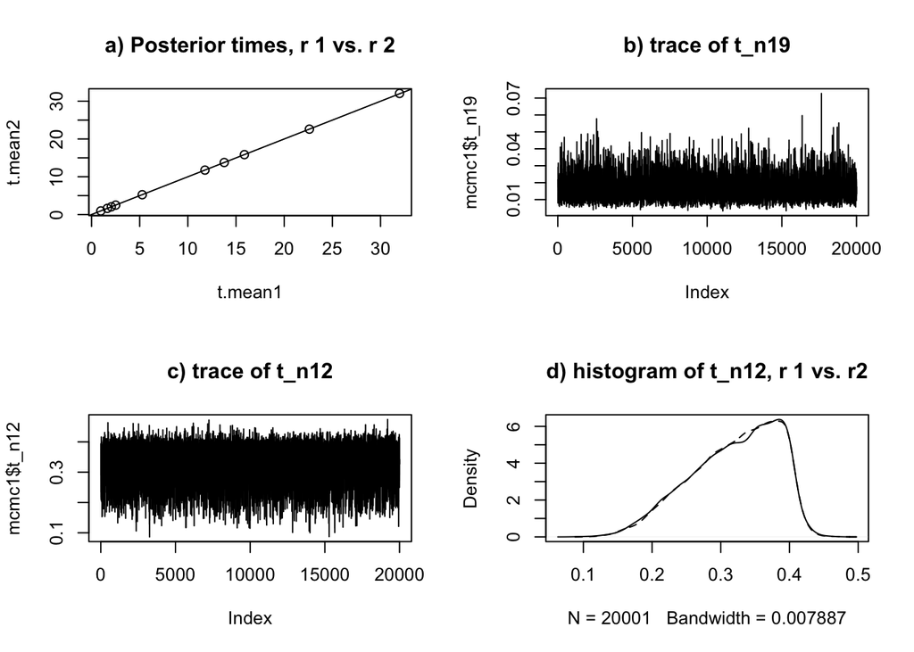

Plotting autocorrelation of the different variables that are included in the model. Ideally, the autocorrelation quickly decreases and reaches 0.

Here is the autocorrelation for the first mcmc run.

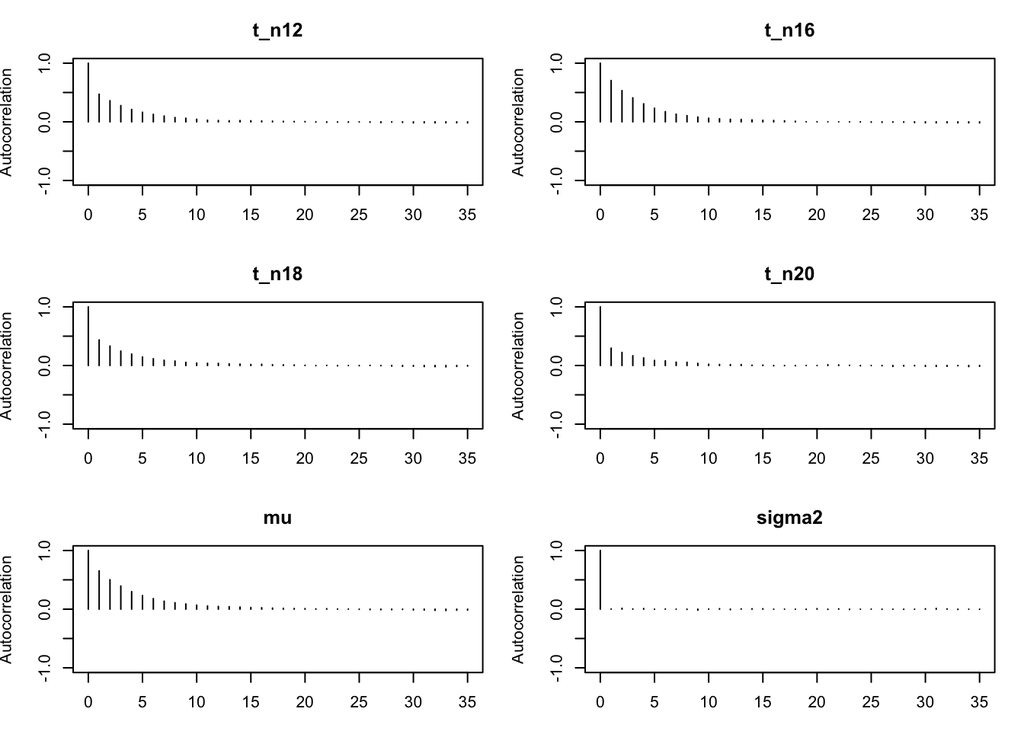

We can calculate the effective sample sizes (ESS) of the parameters (using the coda package).

```
##          mean.mcmc  ess.mcmc     var.mcmc      se.mcmc
## t_n12   0.31972581  4026.402 4.034584e-03 1.001015e-03
## t_n13   0.22615764  3068.522 3.058312e-03 9.983349e-04
## t_n14   0.15867887  2833.105 1.702518e-03 7.752013e-04
## t_n15   0.13772706  2820.630 1.333622e-03 6.876118e-04
## t_n16   0.11772948  2878.240 1.040582e-03 6.012772e-04
## t_n17   0.05263263  3607.785 2.499517e-04 2.632132e-04
## t_n18   0.02504627  4291.444 6.558448e-05 1.236229e-04
## t_n19   0.01636983  5146.743 3.357708e-05 8.077095e-05
## t_n20   0.00962752  5696.576 1.325808e-05 4.824290e-05
## t_n21   0.02050906  5127.478 5.797059e-05 1.063291e-04
## mu      0.37545235  2956.871 1.076657e-02 1.908194e-03
## sigma2  0.13724555 19312.798 4.583747e-03 4.871780e-04
## lnL    -9.51058062 20001.000 9.565757e+00 2.186925e-02
```

The ESS should ideally be >1000.

# Prior

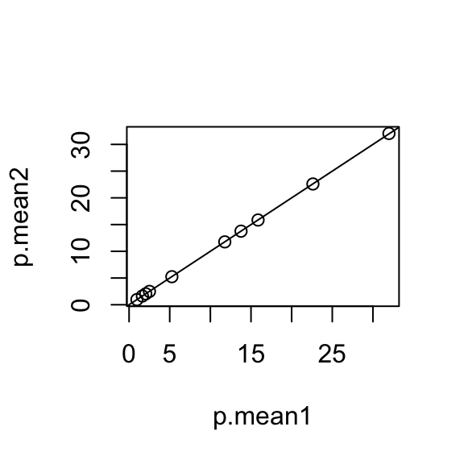

```r
p.mean1 <- apply(mcmc1[,2:11], 2, mean) * 100
p.mean2 <- apply(mcmc2[,2:11], 2, mean) * 100
plot(p.mean1, p.mean2); abline(0, 1)
```

Compare the prior and the posterior for each variable.

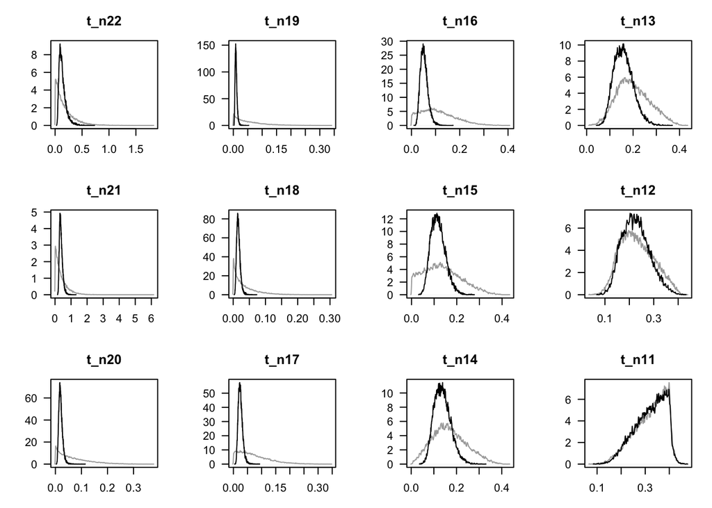

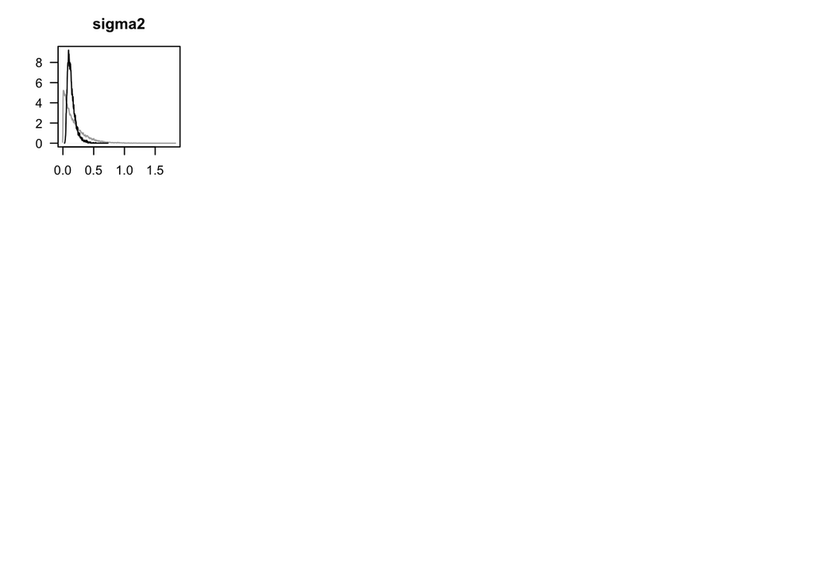

This looks ok and we don’t see substantial incompatibilities between prior and posterior distribution.

Now, we plot the tree with the appropriate error bars.

Prepare plotting

# Run3

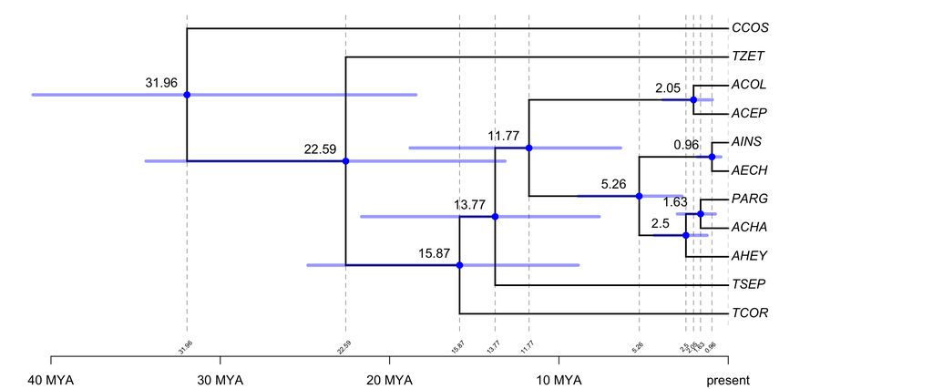

```
##        mean 95%_lower 95%_upper
## 12 0.319649 0.1844530 0.4106120
## 13 0.225899 0.1318290 0.3438430
## 14 0.158659 0.0885895 0.2482070
## 15 0.137675 0.0761859 0.2165450
## 16 0.117662 0.0635818 0.1878470
## 17 0.052584 0.0273810 0.0885552
## 18 0.024993 0.0124874 0.0437197
## 19 0.016347 0.0076571 0.0300586
## 20 0.009618 0.0043849 0.0183708
## 21 0.020491 0.0093697 0.0385053
```

# Run4

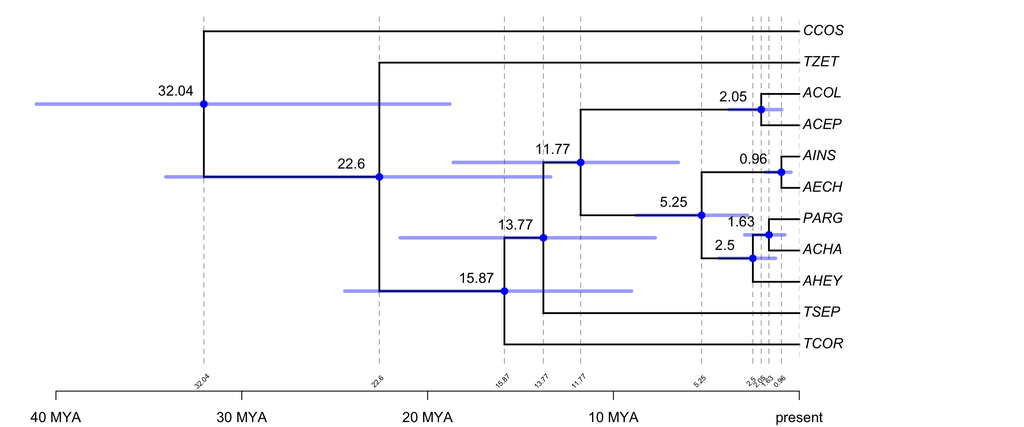

```
##        mean 95%_lower 95%_upper
## 12 0.320405 0.1880640 0.4105110
## 13 0.225977 0.1338070 0.3409070
## 14 0.158672 0.0902896 0.2445550
## 15 0.137710 0.0774672 0.2147520
## 16 0.117665 0.0650718 0.1862380
## 17 0.052550 0.0277912 0.0878476
## 18 0.024983 0.0128068 0.0431821
## 19 0.016335 0.0077802 0.0293585
## 20 0.009605 0.0044259 0.0183199
## 21 0.020492 0.0094895 0.0379604
```